# The Statistics of Australian Rules Football

## Loading required packages

```r
# Ensure all packages are loaded
require(lubridate)
require(dplyr)
require(ggplot2)
require(tibble)
require(readr)
require(magrittr)
require(SparkR)
```

## Importing the dataset

We use readr from the tidyverse to import the dataset. The readr package can predict the type of data in each column

```r
df = readr::read_csv("../data/stats.2017.csv")
```

## Glimpse the dataset.

It’s always important to check out what the data looks like before we start to play with it.

```r
df %>% glimpse()
```

```
## Observations: 195
## Variables: 51
## $ Date                       <dttm> 2017-03-23 19:20:00, 2017-03-24 19...
## $ Team_home                  <chr> "Carlton", "Collingwood", "St Kilda...
## $ Team_away                  <chr> "Richmond", "Western Bulldogs", "Me...
## $ Quarters_home              <chr> "  4.3   7.4  12.4  14.5", "  1.5  ...
## $ Quarters_away              <chr> "  7.3  13.5 15.11 20.12", "  5.1  ...
## $ Total_home                 <int> 89, 86, 90, 82, 116, 96, 93, 147, 7...
## $ Total_away                 <int> 132, 100, 120, 110, 91, 98, 136, 91...
## $ Kicks_home                 <int> 215, 246, 179, 208, 256, 198, 168, ...
## $ Marks_home                 <int> 99, 118, 64, 88, 135, 78, 54, 91, 8...
## $ Handballs_home             <int> 133, 185, 158, 150, 172, 169, 173, ...
## $ Disposals_home             <int> 348, 431, 337, 358, 428, 367, 341, ...
## $ Goals_home                 <int> 14, 12, 13, 12, 17, 14, 13, 22, 10,...
## $ Behinds_home               <int> 5, 14, 12, 10, 14, 12, 15, 15, 13, ...
```

[output cut: 38 more lines]

## Basic additions to the data

This dataset doesn’t actually contain the winner of each game. This is rather important for evaluating downstream statistics

```r
# Calculate the winner of each game and add to initial dataframe as a column
df = df %>%
    dplyr::mutate(Winner_int = dplyr::case_when(Total_home > Total_away ~ 1,
                                                Total_away > Total_home ~ -1,
                                                Total_home == Total_away ~ 0),
                  Team_winner = dplyr::case_when(Total_home > Total_away ~ Team_home,
                                                Total_away > Total_home ~ Team_away,
                                                Total_home == Total_away ~ NA_character_),
                  Margin = Total_home - Total_away)
```

## Question 1: Do free kicks influence games?

*Those lousy white maggots! I tell ya, every time, free kick Hawthorn* Most fans would say yes. Most fans would also say that it is their team that falls victim them most. Except for Hawthorn supports, who have consistently failed to speak out on the issue of bad umpire decisions. It’s easy to hold the moral high-ground when you’ve just won three premiership. Hawthorn fans, however, might just have this one.

#### Define a new dataset and add the columns

```r
# Correlate free kicks against the winner of a game and save as new dataset
df.frees <- df %>%
                dplyr::mutate(FreesFor_diff = FreesFor_home - FreesFor_away) %>%
                dplyr::filter(Margin != 0) %>% # Stop us multiplying/dividing by zero
                dplyr::mutate(Frees_diff = FreesFor_diff*sign(Margin),
                              Margin_frees = Margin*sign(FreesFor_diff))
```

#### Use a scatter plot to show the influence of free kicks on match margins

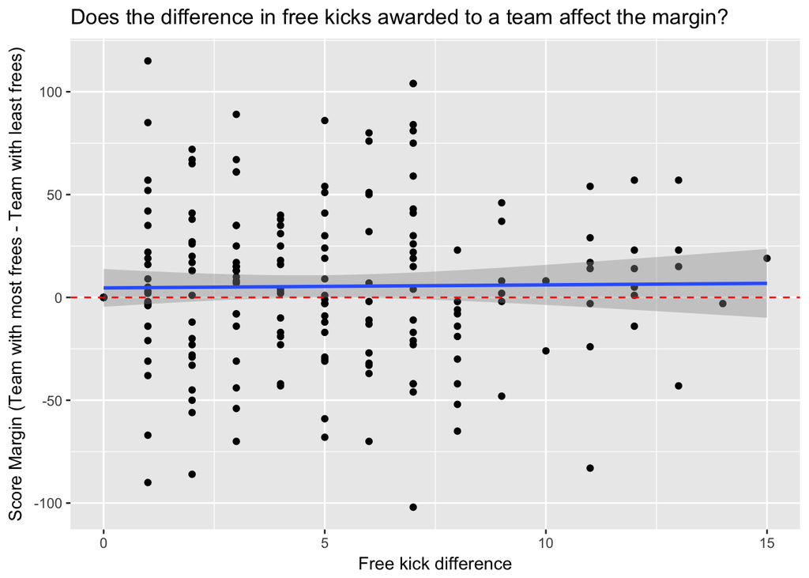

```r
df.frees %>%
    ggplot2::ggplot(aes(x=abs(FreesFor_diff),
                        y=Margin_frees)) +
    ggplot2::geom_point() +
    ggplot2::ylab("Score Margin (Team with most frees - Team with least frees)") +
    ggplot2::xlab("Free kick difference") +
    ggplot2::ggtitle("Does the difference in free kicks awarded to a team affect the margin?") +
    ggplot2::geom_smooth(method="lm", se=TRUE) +
    ggplot2::geom_hline(yintercept=0, linetype="dashed", colour='red')
```